# Spatial tools in R

2015-9-30

## Software and database engineer (2013 - current)

- Australian Antarctic Division, Department of Environment
- work with all kinds of spatial / temporal data and models
- primary software is R programming
- PhD in animal movement models, and integrating environmental data streams
- worked on various now-defunct projects
- web mapping pre-Google maps (mapIQ)
- online gambling (TOTE)
- super-modern 4D GIS (Myriax)

## Ecosystem modelling

Data and programming support for Ecosystem Modelling

- coupling ecosystem and physical ocean models
- software pipelines with a variety of spatial formats and structures:
- polygons, transect lines, animal movement models, remote sensing data, physical models

Lots of juggling of different coordinate systems

## Sea ice data

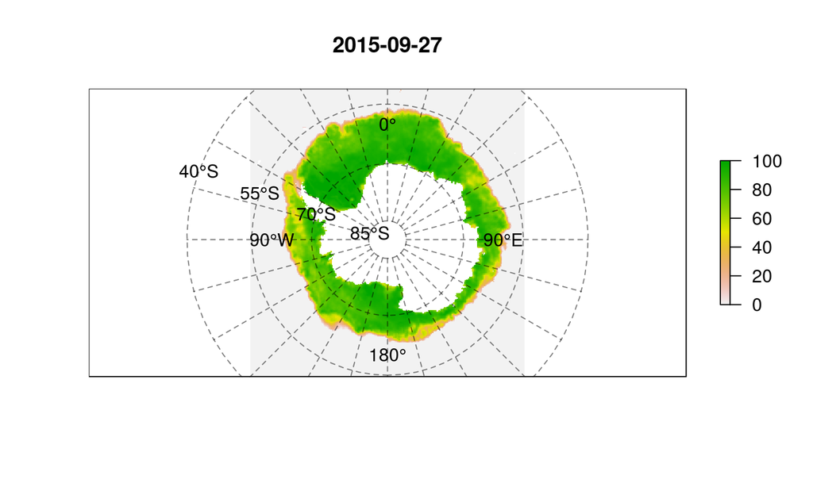

## Ecosystem data

Data currency is crucial

- endless streams of scientific collection, remote sensing, model outputs
- remote sensing data library - automatically kept up to date

Map projections are crucial

- daily sea ice maps
- model structures that traverse the dateline (polygons, transects, 3D meshes)
- characterization of shape and scale

## Ecosystem models

[figure not shown]

## Ocean physical models

[figure not shown]

## Assessment of habitat change

[figure not shown]

## Assessment of habitat change

[figure not shown]

## Summary

- plotting data on a map
- controlling plot region and orientation
- there's more than one way to do it
- longlat maps
- projected maps
- 3D maps

## Raw data

```r
f <- "SAZSENSE_TM_20120209.txt"
szt <- read.table(f, comment.char = "/", sep = "\t", header = TRUE)
summary(szt)
```

```
##     Cruise       Station   Type                  date         Lon
##  AA0307:148   10     :12   B:148   0007-01-20T16:53:12   Min.   :140.5
##               12     :12           0007-01-22T18:25:12   1st Qu.:145.9
##               2b     :12           0007-01-29T23:15:12   Median :149.4
##               4a     :12           0007-02-01T08:53:12   Mean   :148.5
##               5      :12           0007-02-08T06:52:12   3rd Qu.:152.5
##               6a     :12           0007-02-09T00:45:12   Max.   :153.7
##               (Other):76           (Other)         :76
##       Lat            BotDepth          Depth              Al
##  Min.   :-53.99   Min.   : 250.0   Min.   :  15.0   Min.   :0.0970
##  1st Qu.:-49.00   1st Qu.: 500.0   1st Qu.:  50.0   1st Qu.:0.4233
##  Median :-45.58   Median :1000.0   Median : 125.0   Median :0.8215
##  Mean   :-47.22   Mean   : 764.9   Mean   : 225.6   Mean   :1.6875
##  3rd Qu.:-44.95   3rd Qu.:1000.0   3rd Qu.: 262.5   3rd Qu.:2.3213
##  Max.   :-43.69   Max.   :1000.0   Max.   :1000.0   Max.   :7.3430
##                                                     NA's   :2
##        Co              Ni              Cu               Zn
##  Min.   : 5.20   Min.   :2.510   Min.   :0.2170   Min.   : 0.1000
##  1st Qu.:15.60   1st Qu.:3.527   1st Qu.:0.4622   1st Qu.: 0.9275
##  Median :25.35   Median :4.045   Median :0.5430   Median : 1.9600
##  Mean   :23.40   Mean   :4.258   Mean   :0.6068   Mean   : 3.2236
##  3rd Qu.:29.80   3rd Qu.:4.718   3rd Qu.:0.6432   3rd Qu.: 4.1150
##  Max.   :42.90   Max.   :7.310   Max.   :1.7930   Max.   :17.7400
##
##        Cd               Pb               Fe
##  Min.   : -6.20   Min.   :  7.40   Min.   :0.0900
##  1st Qu.: 47.85   1st Qu.: 17.82   1st Qu.:0.1900
##  Median :164.10   Median : 23.15   Median :0.2700
##  Mean   :198.23   Mean   : 29.00   Mean   :0.2849
##  3rd Qu.:247.88   3rd Qu.: 32.90   3rd Qu.:0.3600
##  Max.   :900.40   Max.   :128.40   Max.   :0.6900
##
```

## Take me to the map

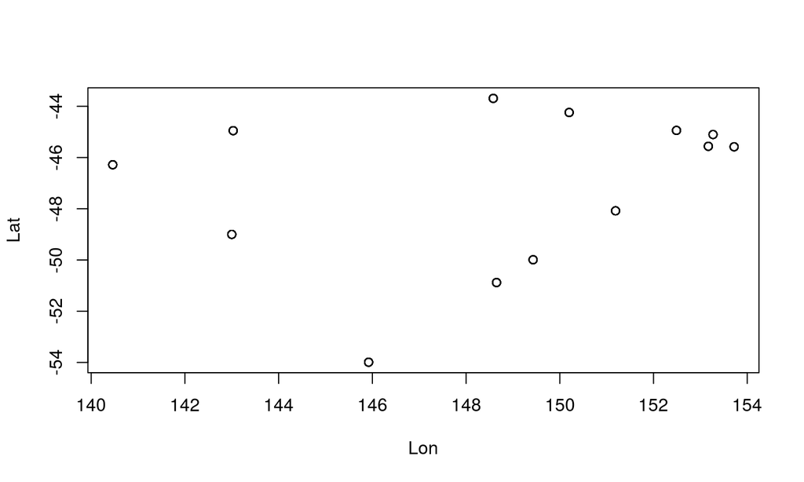

```r
plot(Lat ~ Lon, data = szt)
```

## "I just want a map of my data"

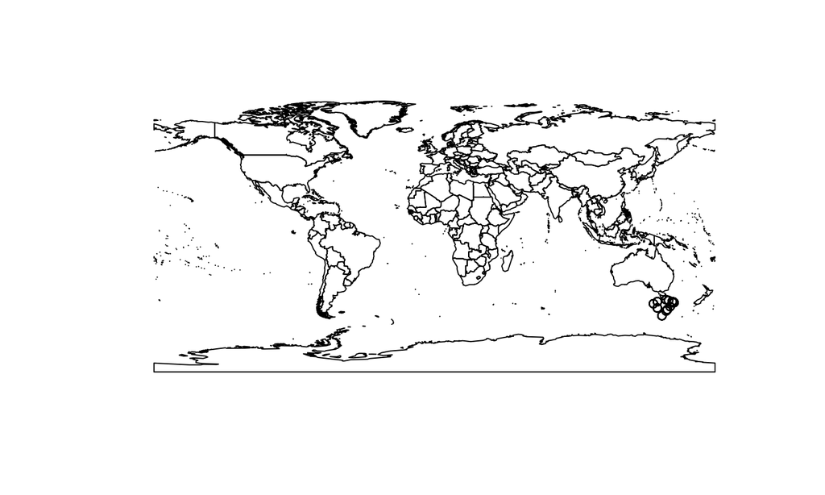

```r
library(maptools)
data(wrld_simpl)
plot(wrld_simpl)
points(Lat ~ Lon, data = szt)
```

## Context 1

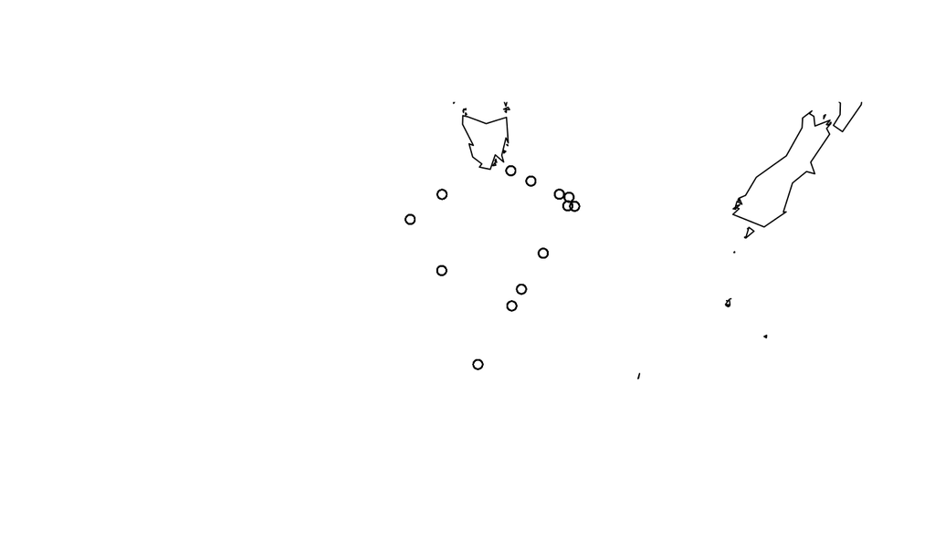

```r
plot(wrld_simpl, xlim = range(szt$Lon) + c(-5, 5),
                  ylim = range(szt$Lat) + c(-3, 3))
points(Lat ~ Lon, data = szt)
```

## Context 2

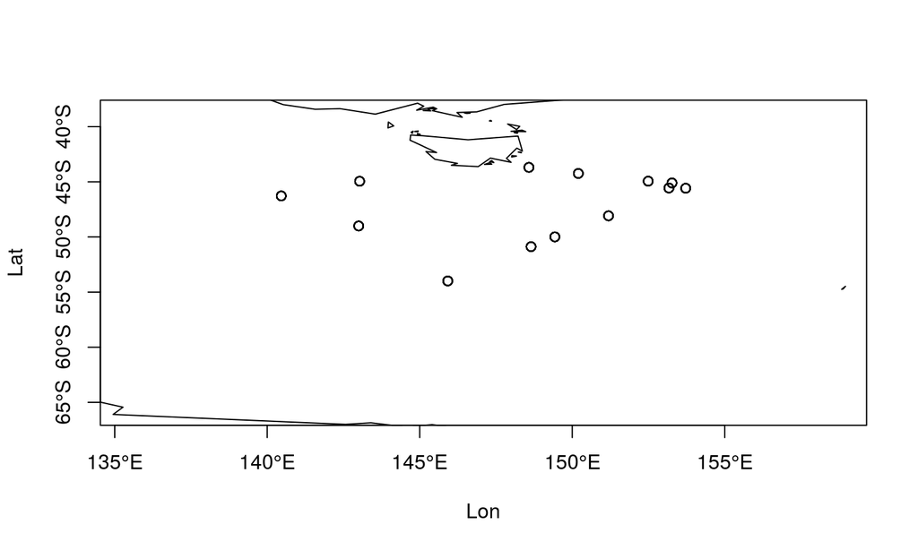

```r
plot(Lat ~ Lon, data = szt, xlim = range(szt$Lon) + c(-5, 5),
     ylim = range(szt$Lat) + c(-12, 5), axes = FALSE)
plot(wrld_simpl, add = TRUE)
degAxis(1);degAxis(2);box()
```

## Map scales - aspect ratio

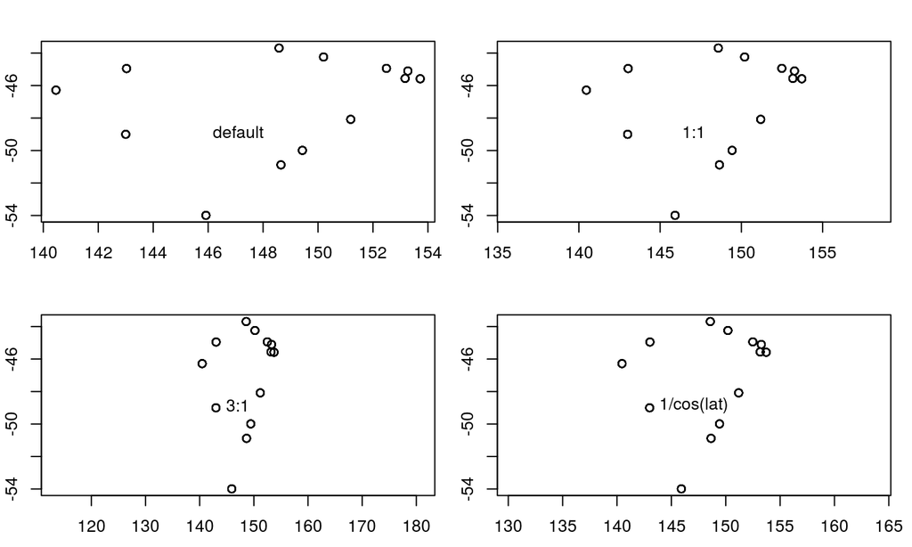

## Map scales - aspect ratio "default"

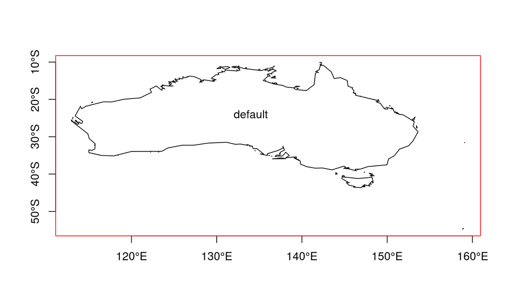

```r
plot(subset(wrld_simpl, NAME == "Australia"), asp = "")
```

## Map scales - aspect ratio "iso"

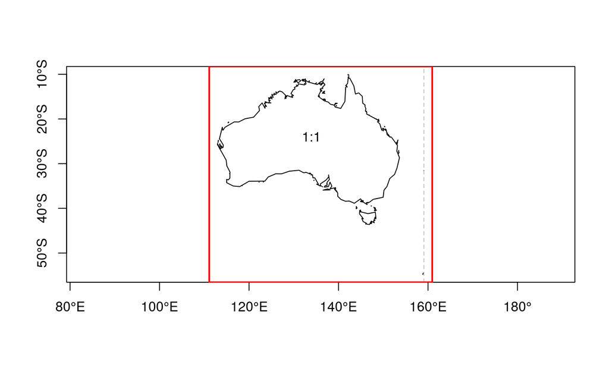

```r
plot(subset(wrld_simpl, NAME == "Australia"), asp = 1)
```

## Map scales - aspect ratio "1/cos(lat)"

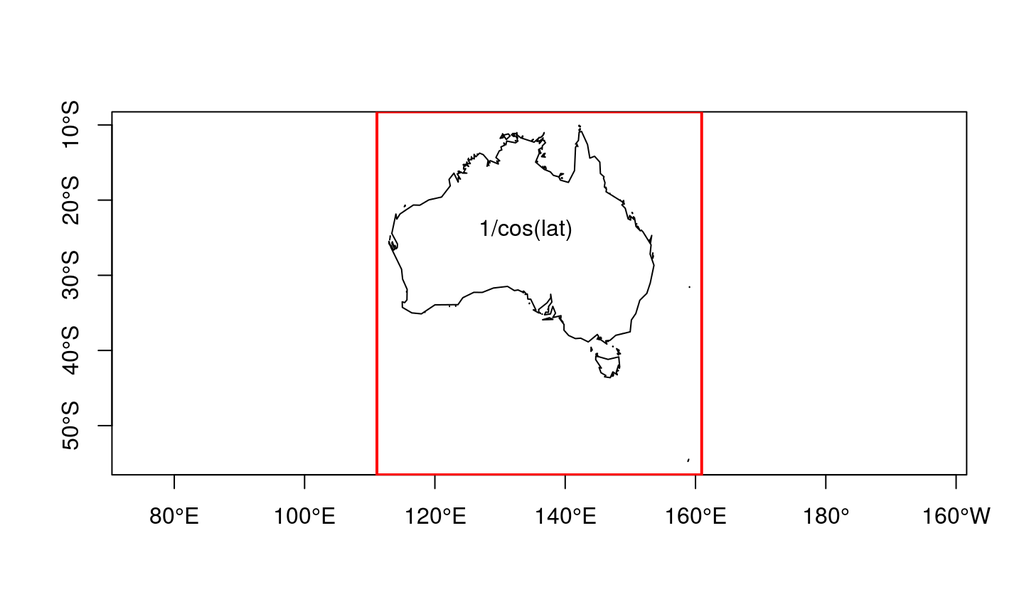

```r
plot(subset(wrld_simpl, NAME == "Australia"), asp = 1/cos(-30 * pi/180))
```

## xlim/ylim/asp aren't enough

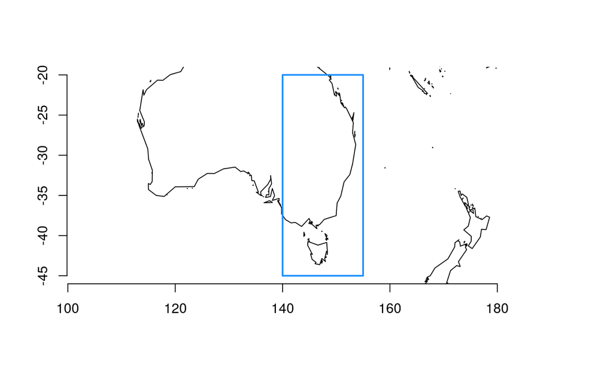

```r
xx <- c(140, 155); yy <- c(-45, -20)
plot(wrld_simpl, xlim = xx, ylim = yy, asp = 1.5); axis(1);axis(2)
rect(xx[1], yy[1], xx[2], yy[2], border = "dodgerblue", lwd = 2)
```

## Control your plot

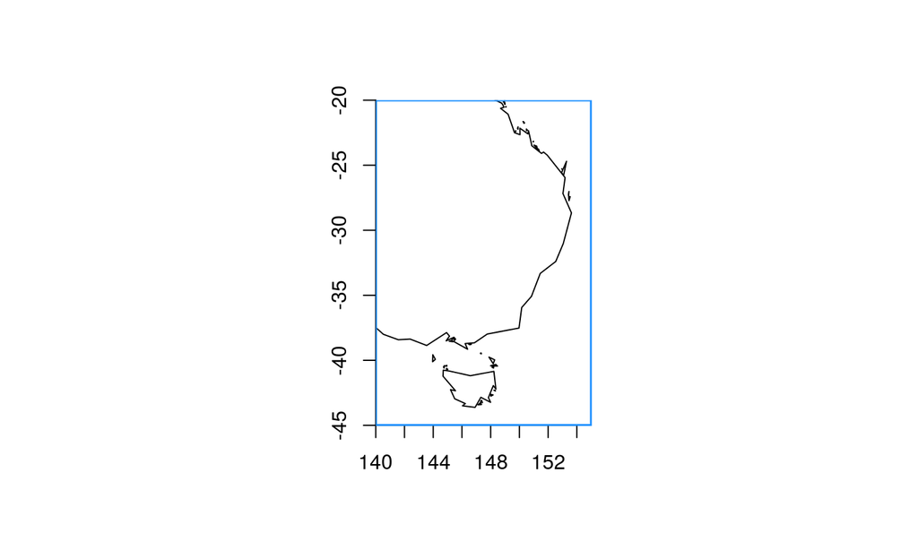

```r
source("aspectplot.R") ## thanks Spoon
op <- aspectplot(xlim = xx, ylim = yy, asp = 1.5)
plot(wrld_simpl, add = TRUE); axis(1);axis(2)
rect(xx[1], yy[1], xx[2], yy[2], border = "dodgerblue", lwd = 2)
```

```r
par(op)
```

## Source your own

```r
library(raster)
help(getData)
library(rgdal)
help(readOGR)
```

GDAL can read vector data from **anywhere**, in R, QGIS, Python, others.

This vector list (2014) keeps growing, the raster list much longer:

**Vector drivers**: <sup><sub>ARCGEN, AVCBin, AVCE00, AeronavFAA, BNA, CSV, CartoDB, CouchDB, DGN, DXF, EDIGEO, ESRI Shapefile, ElasticSearch, GFT, GME, GML, GMT, GPKG, GPSBabel, GPSTrackMaker, GPX, GeoJSON, GeoRSS, Geoconcept, Geomedia, HTF, Idrisi, Interlis 1, Interlis 2, KML, MSSQLSpatial, MapInfo File, Memory, NAS, ODBC, ODS, OSM, OpenAir, OpenFileGDB, PCIDSK, PDF, PDS, PGDump, PGeo, PostgreSQL, REC, S57, SDTS, SEGUKOOA, SEGY, SQLite, SUA, SVG, SXF, TIGER, UK .NTF, VFK, VRT, WAsP, WFS, Walk, XLSX, XPlane</sub></sup>

```r
## Map scales - point size by data

scl <- function(x) (x - min(x, na.rm = TRUE))/diff(range(x, na.rm = TRUE))
plot(Lat ~ Lon, data = szt, cex = scl(sqrt(Al)) * 2 + 1)
```

[output not shown]

```r
## Scales - point size by data
scl <- function(x) (x - min(x, na.rm = TRUE))/diff(range(x, na.rm = TRUE))
plot(Al ~ Depth, data = szt, cex = scl(sqrt(Al)) * 2 + 1)
```

[output not shown]

## Final R map

```r
library(rgdal)

prj <- "+proj=laea +lat_0=-52 +lon_0=147 +x_0=0 +y_0=0 +ellps=WGS84 +towgs84=0,0,0,0,0,0,0 +units=m +no_defs"
oz2 <- spTransform(oz, CRS(prj))
nz2 <- spTransform(nz, CRS(prj))
ant2 <- spTransform(ant, CRS(prj))
xy <- project(cbind(szt$Lon, szt$Lat), prj)
ex <- 0.5 * union(extent(oz2), union(extent(nz2), extent(ant2)))
plot(ex, type = "n", asp = 1, axes = FALSE, xlab = "", ylab = "")
plot(oz2, add = TRUE, col = "grey", border = "transparent")
plot(nz2, add = TRUE, col = "firebrick", border = "transparent")
plot(ant2, add = TRUE, col = "dodgerblue", border = "transparent")
points(xy, cex = scl(sqrt(szt$Al)) * 1.5 + 1)
```

## Use a map projection

[figure not shown]

## QGIS

[figure not shown]

## 3D stuff in R

OpenGL (and WebGL) provide accessible tools for visualization:

https://www.opengl.org/

GIS data needs massaging to use in OpenGL/WebGL:

- normalize polygons into a database structure: vertices, rings, objects
- triangulate vertices with constraints (alignment to polygon edges)
- optionally - triangulate with internal vertices, a maximum triangle size
- convert images/rasters to quad mesh
- each pixel defined by its four corners

## Why 3D?

Extract from International Bathymetric Chart of the Southern Ocean

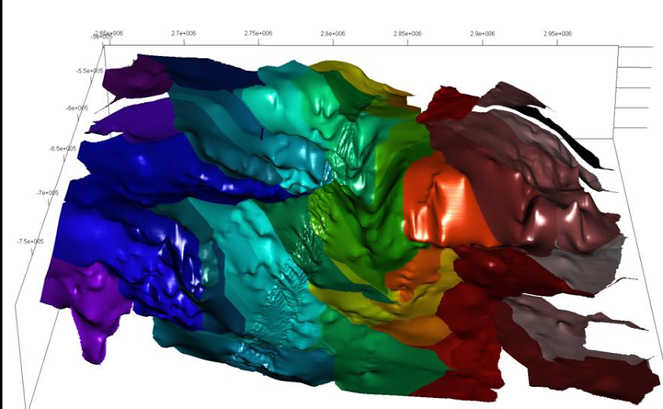

## Links

World outlines source: http://www.gadm.org/

QGIS: www.qgis.org

GDAL: www.gdal.org

OSGEO installer for Windows: http://trac.osgeo.org/osgeo4w/

Mesh structures from GIS data: https://github.com/mdsumner/gris

mdsumner@gmail.com

michael.sumner@aad.gov.au

Australian Antarctic Division